# COMPSCIX 415.2 Homework 5/Midterm

# Visualization (6 points)

```r
# 1. The title "MRS. President" This title need to be bolded.
# 2. The bubbles are not explained or clear and the colors do not have an explaination or legend. Why are M/F color and not others.
# 3. We don't know what the numbers in the bubbles mean. Are they percentage?
```

[output not shown]

2. Reproduce this graphic using the diamonds data set.

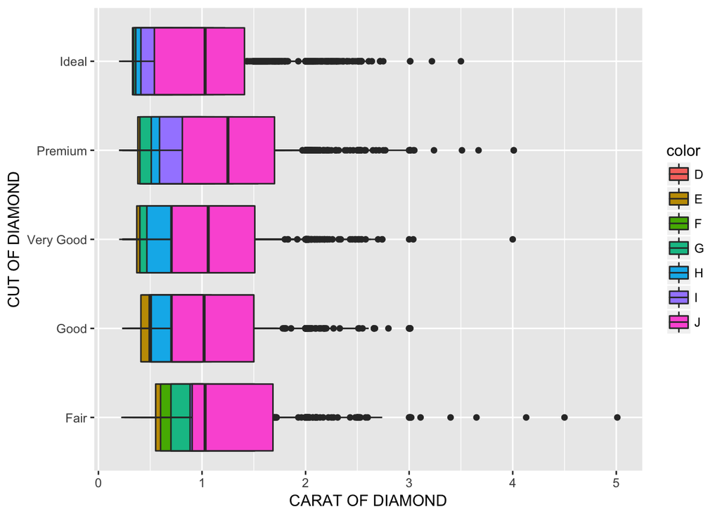

```r
ggplot(data = diamonds) +
  geom_boxplot( mapping = aes(x = cut, y = carat, fill = color), position = 'identity')+
  ylab('CARAT OF DIAMOND') +
  xlab('CUT OF DIAMOND')+
  coord_flip()
```

3. The previous graphic is not very useful. We can make it much more useful by changing one thing about it. Make the change and plot it again.

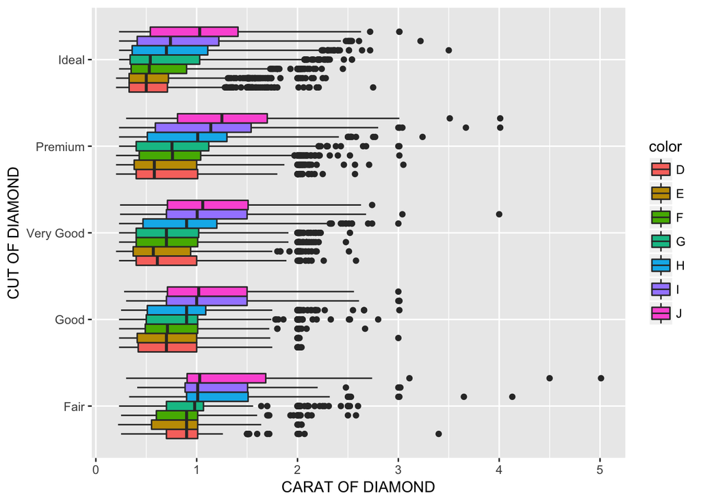

```r
# Dodge position allowes you to see and compare the carat's distribution  for each diamond cut and color.
ggplot(data = diamonds) +
  geom_boxplot( mapping = aes(x = cut, y = carat, fill = color), position = 'dodge')+
  ylab('CARAT OF DIAMOND') +
  xlab('CUT OF DIAMOND')+
  coord_flip()
```

# Data munging and wrangling (6 points)

1. Is this data “tidy”? If yes, leave it alone and go to the next problem. If no, make it tidy. Note: this data set is called table2 and is available in the tidyverse package. It should be ready for you to use after you’ve loaded the tidyverse package.

```r
table2
```

```
## # A tibble: 12 x 4
##    country      year type            count
##    <chr>       <int> <chr>           <int>
##  1 Afghanistan  1999 cases             745
##  2 Afghanistan  1999 population   19987071
##  3 Afghanistan  2000 cases            2666
##  4 Afghanistan  2000 population   20595360
##  5 Brazil       1999 cases           37737
##  6 Brazil       1999 population  172006362
##  7 Brazil       2000 cases           80488
##  8 Brazil       2000 population  174504898
##  9 China        1999 cases          212258
## 10 China        1999 population 1272915272
## 11 China        2000 cases          213766
## 12 China        2000 population 1280428583
```

```r
# The above table2 the type column and count column didn't make sense.
# It makes more sense to list the case with its number as a column and the population and it's counts as a #separate column. Otherwise you have to look left to right and it will be hard to filter the data.
spread(table2, key = type, value = count)
```

```
## # A tibble: 6 x 4
##   country      year  cases population
##   <chr>       <int>  <int>      <int>
## 1 Afghanistan  1999    745   19987071
## 2 Afghanistan  2000   2666   20595360
## 3 Brazil       1999  37737  172006362
## 4 Brazil       2000  80488  174504898
## 5 China        1999 212258 1272915272
## 6 China        2000 213766 1280428583
```

2. Create a new column in the diamonds data set called price_per_carat that shows the price of each diamond per carat (hint: divide). Only show me the code, not the output.

```r
diamonds <- diamonds %>% mutate(price_per_carat = price/carat)
```

3. For each cut of diamond in the diamonds data set, how many diamonds, and what proportion, have a price > 10000 and a carat < 1.5? There are several ways to get to an answer, but your solution must use the data wrangling verbs from the tidyverse in order to get credit.

```r
smalldiamonds <- diamonds %>% group_by(cut) %>%
  summarize(
    number_of_diamonds = n(),
    group_below10K_smaller1.5carat = sum(price > 10000 & carat < 1.5),
    group_proportion = mean(price > 10000 & carat < 1.5)
  )
smalldiamonds
```

```
## # A tibble: 5 x 4
##   cut       number_of_diamonds group_below10K_smaller1.5… group_proportion
##   <ord>                  <int>                      <int>            <dbl>
## 1 Fair                    1610                          4          0.00248
## 2 Good                    4906                         17          0.00347
## 3 Very Good              12082                        155          0.0128
## 4 Premium                13791                        173          0.0125
## 5 Ideal                  21551                        485          0.0225
```

```r
dataset <- filter(diamonds, price>10000 & carat < 1.5)
dataset
```

```
## # A tibble: 834 x 11
##    carat cut       color clarity depth table price     x     y     z
##    <dbl> <ord>     <ord> <ord>   <dbl> <dbl> <int> <dbl> <dbl> <dbl>
##  1  1.03 Ideal     E     VVS2     60.6    59 10003  6.5   6.53  3.95
##  2  1.23 Very Good G     VVS2     60.6    55 10004  6.93  7.02  4.23
##  3  1.25 Ideal     F     VS2      61.6    55 10006  6.93  6.96  4.28
##  4  1.21 Very Good F     VS1      62.3    58 10009  6.76  6.85  4.24
##  5  1.01 Fair      D     SI2      64.6    58 10011  6.25  6.2   4.02
##  6  1.05 Ideal     F     VVS2     60.5    55 10011  6.67  6.58  4.01
##  7  1.35 Premium   G     VS1      62.1    59 10012  7.06  7.02  4.37
##  8  1.13 Ideal     F     VS1      60.9    57 10016  6.73  6.76  4.11
##  9  1.21 Premium   F     VS1      62.6    59 10018  6.81  6.76  4.25
## 10  1.01 Very Good F     VVS1     62.9    57 10019  6.35  6.41  4.01
## # ... with 824 more rows, and 1 more variable: price_per_carat <dbl>
```

3A. Do the results make sense? Why? 3B. Do we need to be wary of any of these numbers? Why?

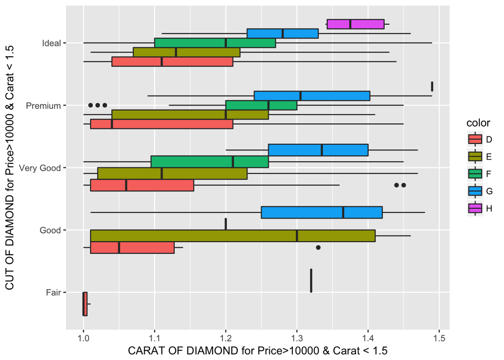

```r
# 3A. Yes the results makes sense, because only a small amount of the diamonds are small less then 1.5 carat # and have a high price over $10,000. When you look at the Y axis you see that there are more higher quality # cut diamonds(ideal, premium and very good) and less cut diamonds at  fair and good quality.
# 3B. Yes, we should be wary of these numbers because the number of diamonds that fit this category is a small subset of diamonds and this can give bias to the over all data. We can have bias in this data set since the sample size is small we get more variation or noise in the data.  If we need to calculate or make predictions with this subset we get a larger or increase in our standard error.
ggplot(data = dataset) +
  geom_boxplot( mapping = aes(x = cut, y = carat, fill = color), position = 'dodge')+
  ylab('CARAT OF DIAMOND for Price>10000 & Carat < 1.5') +
  xlab('CUT OF DIAMOND for Price>10000 & Carat < 1.5')+
  coord_flip()
```

# EDA (6 points)

Take a look at the txhousing data set that is included with the ggplot2 package and answer these questions:

1. During what time period is this data from?

```r
# Between the years of 2000 to 2015
txhousing
```

```
## # A tibble: 8,602 x 9
##    city     year month sales   volume median listings inventory  date
##    <chr>   <int> <int> <dbl>    <dbl>  <dbl>    <dbl>     <dbl> <dbl>
##  1 Abilene  2000     1    72  5380000  71400      701       6.3 2000
##  2 Abilene  2000     2    98  6505000  58700      746       6.6 2000.
##  3 Abilene  2000     3   130  9285000  58100      784       6.8 2000.
##  4 Abilene  2000     4    98  9730000  68600      785       6.9 2000.
##  5 Abilene  2000     5   141 10590000  67300      794       6.8 2000.
##  6 Abilene  2000     6   156 13910000  66900      780       6.6 2000.
##  7 Abilene  2000     7   152 12635000  73500      742       6.2 2000.
##  8 Abilene  2000     8   131 10710000  75000      765       6.4 2001.
##  9 Abilene  2000     9   104  7615000  64500      771       6.5 2001.
## 10 Abilene  2000    10   101  7040000  59300      764       6.6 2001.
## # ... with 8,592 more rows
```

```r
tail(txhousing)
```

```
## # A tibble: 6 x 9
##   city           year month sales   volume median listings inventory  date
##   <chr>         <int> <int> <dbl>    <dbl>  <dbl>    <dbl>     <dbl> <dbl>
## 1 Wichita Falls  2015     2   100 11646765  94000      795       6.8 2015.
## 2 Wichita Falls  2015     3   152 16716584  89200      818       6.8 2015.
## 3 Wichita Falls  2015     4   129 15482194 105300      760       6.4 2015.
## 4 Wichita Falls  2015     5   174 19188181 100000      776       6.4 2015.
## 5 Wichita Falls  2015     6   143 18820752 118800      770       6.2 2015.
## 6 Wichita Falls  2015     7   172 23850905 116700      811       6.5 2016.
```

2. How many cities are represented?

```r
# 46 cities are represented.
nrow(distinct(txhousing, city))
```

```
## [1] 46
```

3. Which city, month and year had the highest number of sales?

```r
# Houston, in July 2015 had the highest number of sales.
txhousing %>%
  group_by(city, month, year) %>%
  arrange(desc(sales))
```

```
## # A tibble: 8,602 x 9
## # Groups:   city, month, year [8,602]
##    city     year month sales     volume median listings inventory  date
##    <chr>   <int> <int> <dbl>      <dbl>  <dbl>    <dbl>     <dbl> <dbl>
##  1 Houston  2015     7  8945 2568156780 217600    23875       3.4 2016.
##  2 Houston  2006     6  8628 1795898108 155200    36281       5.6 2006.
##  3 Houston  2013     7  8468 2168720825 187800    21497       3.3 2014.
##  4 Houston  2015     6  8449 2490238594 222400    22311       3.2 2015.
##  5 Houston  2013     5  8439 2121508529 186100    20526       3.3 2013.
##  6 Houston  2014     6  8391 2342443127 211200    19725       2.9 2014.
##  7 Houston  2014     7  8391 2278932511 199700    20214       3   2014.
##  8 Houston  2014     8  8167 2195184825 202400    20007       2.9 2015.
##  9 Houston  2013     8  8155 2083377894 186700    21366       3.3 2014.
## 10 Houston  2006     5  8040 1602621368 151200    35398       5.5 2006.
## # ... with 8,592 more rows
```

4. What kind of relationship do you think exists between the number of listings and the number of sales? Check your assumption and show your work.

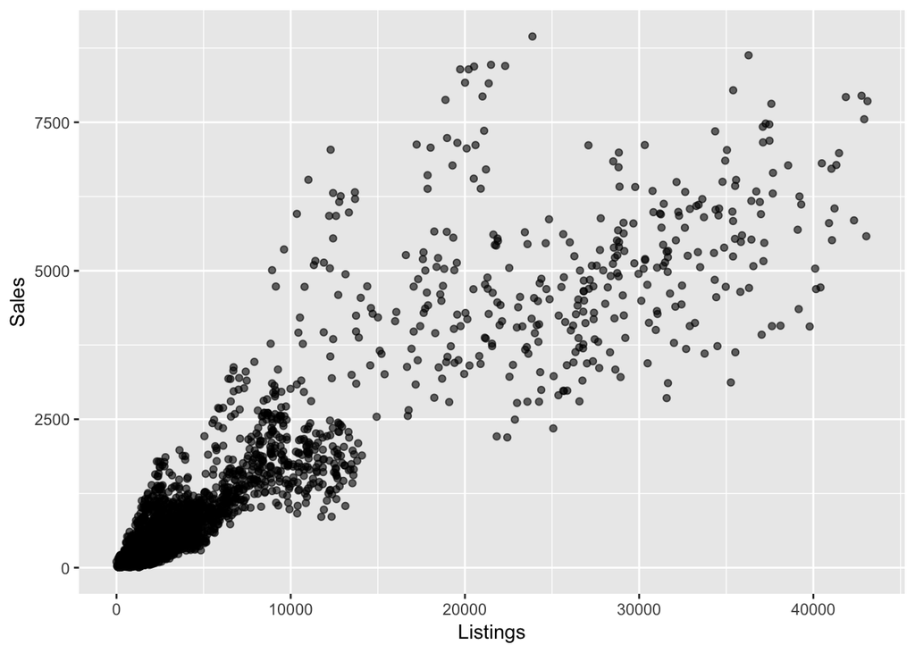

```r
#The relationship between number of listings and number of sales is linearly correlated. As more houses are listed the number of sales house also go up.
ggplot(data = txhousing) +
  geom_point( mapping = aes(x = listings, y = sales), position = 'jitter', alpha=.6)+
  ylab('Sales') +
  xlab('Listings')
```

5. What proportion of sales is missing for each city?

```r
# Here are the missing sales proportion below.
txhousing %>% group_by(city) %>%
  summarize(proportion = mean(is.na(sales)))
```

```
## # A tibble: 46 x 2
##    city                  proportion
##    <chr>                      <dbl>
##  1 Abilene                   0
##  2 Amarillo                  0
##  3 Arlington                 0
##  4 Austin                    0
##  5 Bay Area                  0
##  6 Beaumont                  0
##  7 Brazoria County           0.0749
##  8 Brownsville               0.0107
##  9 Bryan-College Station     0
## 10 Collin County             0
## # ... with 36 more rows
```

6. Looking at only the cities and months with greater than 500 sales:

```r
housesale500 <- txhousing %>% group_by(city, month) %>% filter(sales>500)
housesale500
```

```
## # A tibble: 1,883 x 9
## # Groups:   city, month [153]
##    city       year month sales   volume median listings inventory  date
##    <chr>     <int> <int> <dbl>    <dbl>  <dbl>    <dbl>     <dbl> <dbl>
##  1 Arlington  2000     8   507 60875199 103400     1417       3.5 2001.
##  2 Arlington  2001     5   536 69878959 114400     1592       3.7 2001.
##  3 Arlington  2001     6   534 67744182 108500     1627       3.8 2001.
##  4 Arlington  2001     8   505 65080743 113600     1616       3.7 2002.
##  5 Arlington  2002     5   503 67240236 116100     1741       3.9 2002.
##  6 Arlington  2002     7   509 66954143 119100     1925       4.4 2002.
##  7 Arlington  2003     5   502 67131982 118000     2544       5.9 2003.
##  8 Arlington  2003     7   524 73194692 123500     2799       6.5 2004.
##  9 Arlington  2003     8   531 72397143 123900     2801       6.4 2004.
## 10 Arlington  2004     5   527 72401436 118300     2922       6.5 2004.
## # ... with 1,873 more rows
```

A. Are the distributions of the median sales price (column name median), when grouped by city, different? The same? Show your work.

```r
#6A. Median sale prices when grouped by city are very different.
housesale500 %>% group_by(city) %>%arrange(median)
```

```
## # A tibble: 1,883 x 9
## # Groups:   city [14]
##    city         year month sales    volume median listings inventory  date
##    <chr>       <int> <int> <dbl>     <dbl>  <dbl>    <dbl>     <dbl> <dbl>
##  1 Fort Worth   2000     3   588  57458826  79300     2247       4.3 2000.
##  2 El Paso      2000     8   538  53800000  81700     3396       8   2001.
##  3 Fort Worth   2000     5   630  67131123  81700     2193       4.2 2000.
##  4 El Paso      2002     4   569  54015000  82300     3107       7   2002.
##  5 Fort Worth   2000     7   548  57460916  85100     2362       4.5 2000.
##  6 Fort Worth   2000    10   539  57992200  85300     2573       4.8 2001.
##  7 Fort Worth   2000     6   648  70773279  85900     2212       4.2 2000.
##  8 Fort Worth   2001    10   546  57130944  85900     2769       4.9 2002.
##  9 Fort Worth   2001     3   621  63260951  86000     2511       4.7 2001.
## 10 San Antonio  2000     2  1075 120851076  86000     5933       4.7 2000.
## # ... with 1,873 more rows
```

```r
#6A.
# Here you can see the lowest price of house in Fort Worth and Arlington Texas is lower than the BayArea.
housesale500 %>% group_by(city) %>% summarize(median = median(median)) %>%arrange(median)
```

```
## # A tibble: 14 x 2
##    city              median
##    <chr>              <dbl>
##  1 Fort Worth        114600
##  2 Arlington         129300
##  3 Corpus Christi    129300
##  4 El Paso           131200
##  5 San Antonio       143300
##  6 Houston           148400
##  7 Dallas            154500
##  8 Bay Area          156250
##  9 NE Tarrant County 160800
## 10 Denton County     163200
## 11 Fort Bend         177500
## 12 Montgomery County 178750
## 13 Austin            179400
## 14 Collin County     196000
```

```r
#6A.
# Here you can see that the highest median price of house in Collin Country and Austin is higher than BayArea
housesale500 %>% group_by(city) %>% summarize(median = median(median)) %>% arrange(desc(median))
```

```
## # A tibble: 14 x 2
##    city              median
##    <chr>              <dbl>
##  1 Collin County     196000
##  2 Austin            179400
##  3 Montgomery County 178750
##  4 Fort Bend         177500
##  5 Denton County     163200
##  6 NE Tarrant County 160800
##  7 Bay Area          156250
##  8 Dallas            154500
##  9 Houston           148400
## 10 San Antonio       143300
## 11 El Paso           131200
## 12 Arlington         129300
## 13 Corpus Christi    129300
## 14 Fort Worth        114600
```

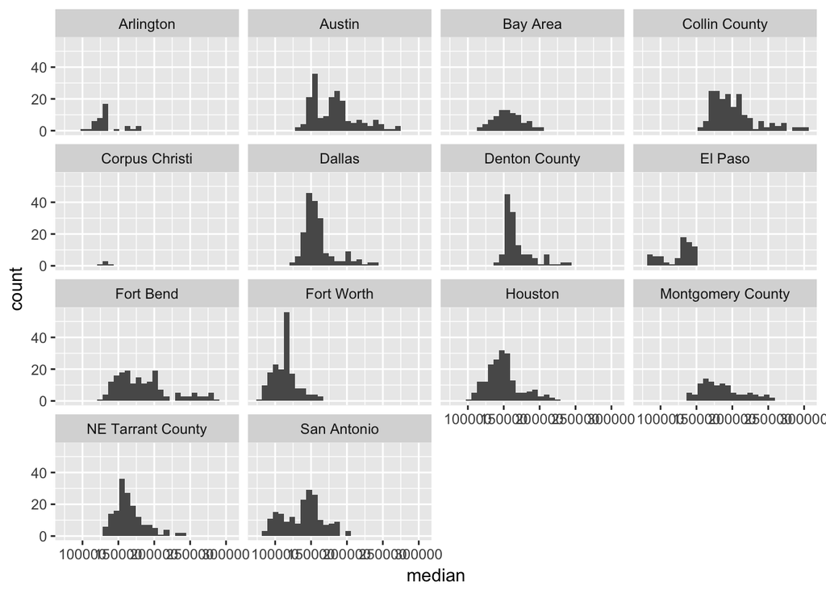

```r
#6A.
# When we look at the median price of houses in a facet we can compare the different cities in a histogram.
# In the facet we can see a lot of varying distibution in each city. Austin, El Paso have bimodal histograms.
# Unimodal histrograms are seen in BayArea, Dallas, Denton County, Collin County, Montgomery County, #FortWorth, Fort Bend, Houston, and NE Tarrant County.
# Collin County, Austin, Denton County, Dallas, Fort Bend,Houston, Montgomery County and NE Tarrant County #have a histogram skewing to the right.
ggplot(housesale500, aes(x = median)) +
  geom_histogram() +
  facet_wrap(~ city)
```

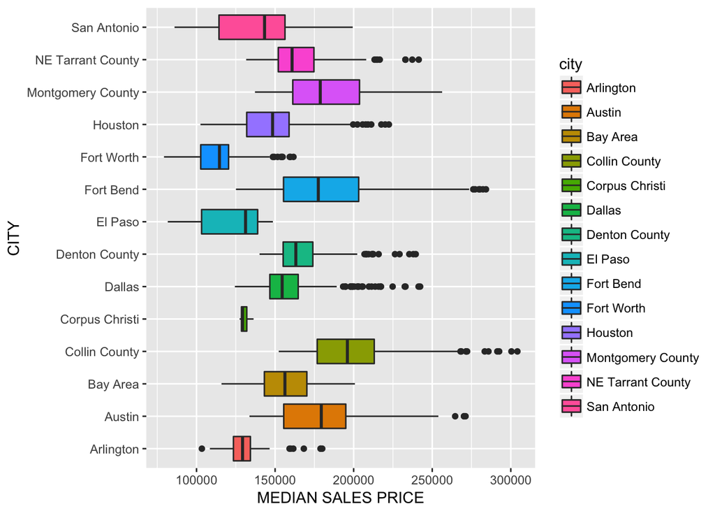

```r
#6A.
ggplot(housesale500) +
  geom_boxplot(aes(x = city, y = median, fill = city), position = 'dodge') +
  xlab("CITY") +
  ylab("MEDIAN SALES PRICE") +
  coord_flip()
```

6B. Any cities that stand out that you’d want to investigate further?

```r
#6B.
# It would be interesting to see why Houston, Dallas, Denton County, Auston and San Antonio and  NE Tarrant County had a spike in median prices at the same time.
# Why does  Austin, El Paso have bimodal histograms.
# Why does  Collin County,Fort Bend, Austin, and Montogomery county have the highest median price.
# Why does Fort Worth, El Paso, Arlington and Corpus Christi have the lowerest median price.
# Why does Corpus Christi have a narrow and stable median price range and Fort Bend and Collin County have a large varying price range.
```

6C. Why might we want to filter out all cities and months with sales less than 500?

```r
# 6C.
# We want to filter out the cities and months with sales less than 500  because we don't want to have any bias from our data set.
# When the sample size increases our standard error decreases.
# When the sample size increase the shape of the distribution is less spread out and less variation or noise in the data.
```